# P2. Investigate a Dataset

## Introduction

[figure not shown]

The task is to explore a provided dataset in order to get some interesting insights, and I chose the [Sean Lahman's baseball database](http://www.seanlahman.com/baseball-archive/statistics/) as the source of data.

I picked it over other options because it looks like something not many people have looked into (Titanic dataset seems to be much more popular), and also since I've been impressed by the story of [Billy Beane](https://en.wikipedia.org/wiki/Billy_Beane), who was the first to apply statistical analysis to the players' data in order to evaluate them.

This became known as ["sabermetrics"](https://en.wikipedia.org/wiki/Sabermetrics) and the whole story was popularized later via a book and a movie ["Moneyball"](https://en.wikipedia.org/wiki/Moneyball).

[figure not shown]

Being a non-american, I also don't have much clue about baseball, so it's a nice opportunity to learn about the sport.

## Questions to the data

Ideally, one would hope to repeat Billy Beane's success and find how player/team performance correlates with different attributes.

But since we yet don't know much about those attributes, let's explore the data first.

## Data exploration

Let's start from the top-down view of the data, and then proceed with drilling into more details.

```python
# initial setup/imports
%matplotlib inline
import os
import IPython.core.display as disp

for _ in range(2):
    try:
        import numpy as np, pandas as pd, seaborn as sns
        import matplotlib as mpl, matplotlib.pyplot as plt
        import chorogrid
        from scipy import stats
    except:
        print('Trying to install the missing libraries...')
        !pip3 install matplotlib numpy pandas seaborn chorogrid scipy
```

### General structure

There is an archive with a set of CSV files and a couple of text files (readme*.txt). Let's unpack the files into the "data" folder.

The CSV files are:

```python
dir_root = "data/2016/"
files = sorted([f for f in os.listdir(dir_root)
                if f.endswith('.csv')])
files
```

```
['AllstarFull.csv',
 'Appearances.csv',
 'AwardsManagers.csv',
 'AwardsPlayers.csv',
 'AwardsShareManagers.csv',
 'AwardsSharePlayers.csv',
 'Batting.csv',
 'BattingPost.csv',
 'CollegePlaying.csv',
 'Fielding.csv',
 'FieldingOF.csv',
 'FieldingOFsplit.csv',
 'FieldingPost.csv',
 'HallOfFame.csv',
 'HomeGames.csv',
 'Managers.csv',
 'ManagersHalf.csv',
 'Master.csv',
 'Parks.csv',
 'Pitching.csv',
 'PitchingPost.csv',
 'Salaries.csv',
 'Schools.csv',
 'SeriesPost.csv',
 'Teams.csv',
 'TeamsFranchises.csv',
 'TeamsHalf.csv']
```

We can see the list of "tables" with data that are available. Also, there is a text file ("readme2016.txt") in the same folder, which has a very short description of each table and its columns. It's a good start.

Let's print the head and statistics for each table.

```python
import pandas as pd

tables = {}
for f in files:
    name = f.split('.')[0]
    tables[name] = pd.read_csv(dir_root + f)

HEADER_FORMAT = '<hr/><h4 style="color:steelblue;">{}</h4>'
def show_table_header(title):
    disp.display(disp.HTML(HEADER_FORMAT.format(title)))

for name in sorted(tables.keys()):
    table = tables[name]
    show_table_header(name)
    disp.display('{} rows'.format(len(table)))
    disp.display(table.head(), table.describe())
```

AllstarFull

```
'5148 rows'
```

|  | playerID | yearID | gameNum | gameID | teamID | lgID | GP | startingPos |
| --- | --- | --- | --- | --- | --- | --- | --- | --- |
| 0 | gomezle01 | 1933 | 0 | ALS193307060 | NYA | AL | 1.0 | 1.0 |
| 1 | ferreri01 | 1933 | 0 | ALS193307060 | BOS | AL | 1.0 | 2.0 |
| 2 | gehrilo01 | 1933 | 0 | ALS193307060 | NYA | AL | 1.0 | 3.0 |
| 3 | gehrich01 | 1933 | 0 | ALS193307060 | DET | AL | 1.0 | 4.0 |
| 4 | dykesji01 | 1933 | 0 | ALS193307060 | CHA | AL | 1.0 | 5.0 |

|  | yearID | gameNum | GP | startingPos |
| --- | --- | --- | --- | --- |
| count | 5148.000000 | 5148.000000 | 5129.000000 | 1600.000000 |
| mean | 1977.040210 | 0.134810 | 0.777929 | 5.031250 |
| std | 24.008874 | 0.458167 | 0.415679 | 2.657007 |
| min | 1933.000000 | 0.000000 | 0.000000 | 0.000000 |
| 25% | 1958.000000 | 0.000000 | 1.000000 | 3.000000 |
| 50% | 1977.000000 | 0.000000 | 1.000000 | 5.000000 |
| 75% | 1999.000000 | 0.000000 | 1.000000 | 7.000000 |
| max | 2016.000000 | 2.000000 | 1.000000 | 10.000000 |

Appearances

```
'102761 rows'
```

|  | yearID | teamID | lgID | playerID | G_all | GS | G_batting | G_defense | G_p | G_c | ... | G_2b | G_3b | G_ss | G_lf | G_cf | G_rf | G_of | G_dh | G_ph | G_pr |
| --- | --- | --- | --- | --- | --- | --- | --- | --- | --- | --- | --- | --- | --- | --- | --- | --- | --- | --- | --- | --- | --- |
| 0 | 1871 | TRO | NaN | abercda01 | 1 | NaN | 1 | 1 | 0 | 0 | ... | 0 | 0 | 1 | 0 | 0 | 0 | 0 | NaN | NaN | NaN |
| 1 | 1871 | RC1 | NaN | addybo01 | 25 | NaN | 25 | 25 | 0 | 0 | ... | 22 | 0 | 3 | 0 | 0 | 0 | 0 | NaN | NaN | NaN |
| 2 | 1871 | CL1 | NaN | allisar01 | 29 | NaN | 29 | 29 | 0 | 0 | ... | 2 | 0 | 0 | 0 | 29 | 0 | 29 | NaN | NaN | NaN |
| 3 | 1871 | WS3 | NaN | allisdo01 | 27 | NaN | 27 | 27 | 0 | 27 | ... | 0 | 0 | 0 | 0 | 0 | 0 | 0 | NaN | NaN | NaN |
| 4 | 1871 | RC1 | NaN | ansonca01 | 25 | NaN | 25 | 25 | 0 | 5 | ... | 2 | 20 | 0 | 1 | 0 | 0 | 1 | NaN | NaN | NaN |

5 rows × 21 columns

|  | yearID | G_all | GS | G_batting | G_defense | G_p | G_c | G_1b | G_2b | G_3b | G_ss | G_lf | G_cf | G_rf | G_of | G_dh | G_ph | G_pr |
| --- | --- | --- | --- | --- | --- | --- | --- | --- | --- | --- | --- | --- | --- | --- | --- | --- | --- | --- |
| count | 102761.000000 | 102761.000000 | 90166.000000 | 102761.000000 | 102761.000000 | 102761.000000 | 102761.000000 | 102761.000000 | 102761.000000 | 102761.000000 | 102761.000000 | 102761.000000 | 102761.000000 | 102761.000000 | 102761.000000 | 90166.000000 | 90166.000000 | 90166.000000 |
| mean | 1964.270219 | 51.380942 | 37.101601 | 48.417571 | 46.845243 | 10.362978 | 4.733615 | 4.588667 | 4.570304 | 4.587548 | 4.558850 | 4.840786 | 4.571005 | 4.702737 | 13.798708 | 1.260952 | 4.397167 | 0.806768 |
| std | 38.851188 | 47.126638 | 47.230209 | 48.889453 | 45.377191 | 16.963018 | 18.928323 | 20.713830 | 20.470539 | 20.325324 | 21.152432 | 19.019660 | 20.190575 | 19.296453 | 34.714992 | 8.443146 | 8.936892 | 2.521176 |
| min | 1871.000000 | 0.000000 | 0.000000 | 0.000000 | 0.000000 | 0.000000 | 0.000000 | 0.000000 | 0.000000 | 0.000000 | 0.000000 | 0.000000 | 0.000000 | 0.000000 | 0.000000 | 0.000000 | 0.000000 | 0.000000 |
| 25% | 1934.000000 | 13.000000 | 1.000000 | 7.000000 | 10.000000 | 0.000000 | 0.000000 | 0.000000 | 0.000000 | 0.000000 | 0.000000 | 0.000000 | 0.000000 | 0.000000 | 0.000000 | 0.000000 | 0.000000 | 0.000000 |
| 50% | 1973.000000 | 34.000000 | 16.000000 | 31.000000 | 32.000000 | 0.000000 | 0.000000 | 0.000000 | 0.000000 | 0.000000 | 0.000000 | 0.000000 | 0.000000 | 0.000000 | 0.000000 | 0.000000 | 0.000000 | 0.000000 |
| 75% | 1998.000000 | 80.000000 | 55.000000 | 80.000000 | 70.000000 | 17.000000 | 0.000000 | 0.000000 | 0.000000 | 0.000000 | 0.000000 | 0.000000 | 0.000000 | 0.000000 | 1.000000 | 0.000000 | 5.000000 | 0.000000 |
| max | 2016.000000 | 165.000000 | 164.000000 | 165.000000 | 165.000000 | 106.000000 | 160.000000 | 162.000000 | 163.000000 | 164.000000 | 165.000000 | 163.000000 | 162.000000 | 162.000000 | 164.000000 | 162.000000 | 95.000000 | 92.000000 |

AwardsManagers

```
'179 rows'
```

|  | playerID | awardID | yearID | lgID | tie | notes |
| --- | --- | --- | --- | --- | --- | --- |
| 0 | larusto01 | BBWAA Manager of the Year | 1983 | AL | NaN | NaN |
| 1 | lasorto01 | BBWAA Manager of the Year | 1983 | NL | NaN | NaN |
| 2 | andersp01 | BBWAA Manager of the Year | 1984 | AL | NaN | NaN |
| 3 | freyji99 | BBWAA Manager of the Year | 1984 | NL | NaN | NaN |
| 4 | coxbo01 | BBWAA Manager of the Year | 1985 | AL | NaN | NaN |

|  | yearID |
| --- | --- |
| count | 179.000000 |
| mean | 1988.921788 |
| std | 20.872123 |
| min | 1936.000000 |
| 25% | 1980.500000 |
| 50% | 1994.000000 |
| 75% | 2005.000000 |
| max | 2016.000000 |

AwardsPlayers

```
'6158 rows'
```

|  | playerID | awardID | yearID | lgID | tie | notes |
| --- | --- | --- | --- | --- | --- | --- |
| 0 | bondto01 | Pitching Triple Crown | 1877 | NL | NaN | NaN |
| 1 | hinespa01 | Triple Crown | 1878 | NL | NaN | NaN |
| 2 | heckegu01 | Pitching Triple Crown | 1884 | AA | NaN | NaN |
| 3 | radboch01 | Pitching Triple Crown | 1884 | NL | NaN | NaN |
| 4 | oneilti01 | Triple Crown | 1887 | AA | NaN | NaN |

|  | yearID |
| --- | --- |
| count | 6158.000000 |
| mean | 1969.076648 |
| std | 30.841987 |
| min | 1877.000000 |
| 25% | 1942.000000 |
| 50% | 1975.000000 |
| 75% | 1995.000000 |
| max | 2016.000000 |

AwardsShareManagers

```
'425 rows'
```

|  | awardID | yearID | lgID | playerID | pointsWon | pointsMax | votesFirst |
| --- | --- | --- | --- | --- | --- | --- | --- |
| 0 | BBWAA Manager of the Year | 1983 | AL | altobjo01 | 7 | 28.0 | 7 |
| 1 | BBWAA Manager of the Year | 1983 | AL | coxbo01 | 4 | 28.0 | 4 |
| 2 | BBWAA Manager of the Year | 1983 | AL | larusto01 | 17 | 28.0 | 17 |
| 3 | BBWAA Manager of the Year | 1983 | NL | lasorto01 | 10 | 24.0 | 10 |
| 4 | BBWAA Manager of the Year | 1983 | NL | lillibo01 | 9 | 24.0 | 9 |

|  | yearID | pointsWon | pointsMax | votesFirst |
| --- | --- | --- | --- | --- |
| count | 425.000000 | 425.000000 | 414.000000 | 425.000000 |
| mean | 2000.197647 | 40.117647 | 141.932367 | 4.567059 |
| std | 9.518527 | 41.601323 | 19.191283 | 7.057436 |
| min | 1983.000000 | 1.000000 | 24.000000 | 0.000000 |
| 25% | 1992.000000 | 4.000000 | 140.000000 | 0.000000 |
| 50% | 2000.000000 | 23.000000 | 140.000000 | 1.000000 |
| 75% | 2009.000000 | 70.000000 | 150.000000 | 6.000000 |
| max | 2016.000000 | 154.000000 | 160.000000 | 30.000000 |

AwardsSharePlayers

```
'6879 rows'
```

|  | awardID | yearID | lgID | playerID | pointsWon | pointsMax | votesFirst |
| --- | --- | --- | --- | --- | --- | --- | --- |
| 0 | Cy Young | 1956 | ML | fordwh01 | 1.0 | 16 | 1.0 |
| 1 | Cy Young | 1956 | ML | maglisa01 | 4.0 | 16 | 4.0 |
| 2 | Cy Young | 1956 | ML | newcodo01 | 10.0 | 16 | 10.0 |
| 3 | Cy Young | 1956 | ML | spahnwa01 | 1.0 | 16 | 1.0 |
| 4 | Cy Young | 1957 | ML | donovdi01 | 1.0 | 16 | 1.0 |

|  | yearID | pointsWon | pointsMax | votesFirst |
| --- | --- | --- | --- | --- |
| count | 6879.000000 | 6879.000000 | 6879.000000 | 6521.000000 |
| mean | 1972.461259 | 43.559674 | 267.518389 | 1.624751 |
| std | 27.707848 | 68.265957 | 128.988138 | 4.911428 |
| min | 1911.000000 | 0.000000 | 16.000000 | 0.000000 |
| 25% | 1950.000000 | 4.000000 | 140.000000 | 0.000000 |
| 50% | 1975.000000 | 12.000000 | 336.000000 | 0.000000 |
| 75% | 1996.000000 | 53.000000 | 336.000000 | 0.000000 |
| max | 2016.000000 | 448.000000 | 448.000000 | 32.000000 |

Batting

```
'102816 rows'
```

|  | playerID | yearID | stint | teamID | lgID | G | AB | R | H | 2B | ... | RBI | SB | CS | BB | SO | IBB | HBP | SH | SF | GIDP |
| --- | --- | --- | --- | --- | --- | --- | --- | --- | --- | --- | --- | --- | --- | --- | --- | --- | --- | --- | --- | --- | --- |
| 0 | abercda01 | 1871 | 1 | TRO | NaN | 1 | 4 | 0 | 0 | 0 | ... | 0.0 | 0.0 | 0.0 | 0 | 0.0 | NaN | NaN | NaN | NaN | NaN |
| 1 | addybo01 | 1871 | 1 | RC1 | NaN | 25 | 118 | 30 | 32 | 6 | ... | 13.0 | 8.0 | 1.0 | 4 | 0.0 | NaN | NaN | NaN | NaN | NaN |
| 2 | allisar01 | 1871 | 1 | CL1 | NaN | 29 | 137 | 28 | 40 | 4 | ... | 19.0 | 3.0 | 1.0 | 2 | 5.0 | NaN | NaN | NaN | NaN | NaN |
| 3 | allisdo01 | 1871 | 1 | WS3 | NaN | 27 | 133 | 28 | 44 | 10 | ... | 27.0 | 1.0 | 1.0 | 0 | 2.0 | NaN | NaN | NaN | NaN | NaN |
| 4 | ansonca01 | 1871 | 1 | RC1 | NaN | 25 | 120 | 29 | 39 | 11 | ... | 16.0 | 6.0 | 2.0 | 2 | 1.0 | NaN | NaN | NaN | NaN | NaN |

5 rows × 22 columns

|  | yearID | stint | G | AB | R | H | 2B | 3B | HR | RBI | SB | CS | BB | SO | IBB | HBP | SH | SF | GIDP |
| --- | --- | --- | --- | --- | --- | --- | --- | --- | --- | --- | --- | --- | --- | --- | --- | --- | --- | --- | --- |
| count | 102816.000000 | 102816.000000 | 102816.000000 | 102816.000000 | 102816.000000 | 102816.000000 | 102816.000000 | 102816.000000 | 102816.000000 | 102392.000000 | 101516.000000 | 79360.000000 | 102816.000000 | 94978.000000 | 66251.000000 | 100006.000000 | 96478.000000 | 66782.000000 | 76706.000000 |
| mean | 1964.262313 | 1.077838 | 51.343439 | 141.905511 | 18.815544 | 37.139930 | 6.289167 | 1.293252 | 2.813599 | 17.003975 | 2.976821 | 1.226008 | 13.067207 | 20.529712 | 1.105870 | 1.056057 | 2.299540 | 1.054101 | 2.981018 |
| std | 38.856297 | 0.284366 | 47.121658 | 184.654492 | 28.242983 | 52.603757 | 9.662468 | 2.645770 | 6.304919 | 26.352011 | 7.717174 | 2.747377 | 20.746460 | 28.328542 | 2.780187 | 2.276251 | 4.241095 | 1.961732 | 4.735153 |
| min | 1871.000000 | 1.000000 | 1.000000 | 0.000000 | 0.000000 | 0.000000 | 0.000000 | 0.000000 | 0.000000 | 0.000000 | 0.000000 | 0.000000 | 0.000000 | 0.000000 | 0.000000 | 0.000000 | 0.000000 | 0.000000 | 0.000000 |
| 25% | 1934.000000 | 1.000000 | 13.000000 | 4.000000 | 0.000000 | 0.000000 | 0.000000 | 0.000000 | 0.000000 | 0.000000 | 0.000000 | 0.000000 | 0.000000 | 1.000000 | 0.000000 | 0.000000 | 0.000000 | 0.000000 | 0.000000 |
| 50% | 1973.000000 | 1.000000 | 34.000000 | 49.000000 | 4.000000 | 9.000000 | 1.000000 | 0.000000 | 0.000000 | 3.000000 | 0.000000 | 0.000000 | 3.000000 | 9.000000 | 0.000000 | 0.000000 | 0.000000 | 0.000000 | 0.000000 |
| 75% | 1998.000000 | 1.000000 | 80.000000 | 231.000000 | 27.000000 | 58.000000 | 9.000000 | 1.000000 | 2.000000 | 24.000000 | 2.000000 | 1.000000 | 18.000000 | 29.000000 | 1.000000 | 1.000000 | 3.000000 | 1.000000 | 4.000000 |
| max | 2016.000000 | 5.000000 | 165.000000 | 716.000000 | 192.000000 | 262.000000 | 67.000000 | 36.000000 | 73.000000 | 191.000000 | 138.000000 | 42.000000 | 232.000000 | 223.000000 | 120.000000 | 51.000000 | 67.000000 | 19.000000 | 36.000000 |

BattingPost

```
'13543 rows'
```

|  | yearID | round | playerID | teamID | lgID | G | AB | R | H | 2B | ... | RBI | SB | CS | BB | SO | IBB | HBP | SH | SF | GIDP |
| --- | --- | --- | --- | --- | --- | --- | --- | --- | --- | --- | --- | --- | --- | --- | --- | --- | --- | --- | --- | --- | --- |
| 0 | 1884 | WS | becanbu01 | NY4 | AA | 1 | 2 | 0 | 1 | 0 | ... | 0 | 0 | NaN | 0 | 0 | 0 | NaN | NaN | NaN | NaN |
| 1 | 1884 | WS | bradyst01 | NY4 | AA | 3 | 10 | 1 | 0 | 0 | ... | 0 | 0 | NaN | 0 | 1 | 0 | NaN | NaN | NaN | NaN |
| 2 | 1884 | WS | carrocl01 | PRO | NL | 3 | 10 | 2 | 1 | 0 | ... | 1 | 0 | NaN | 1 | 1 | 0 | NaN | NaN | NaN | NaN |
| 3 | 1884 | WS | dennyje01 | PRO | NL | 3 | 9 | 3 | 4 | 0 | ... | 2 | 0 | NaN | 0 | 3 | 0 | NaN | NaN | NaN | NaN |
| 4 | 1884 | WS | esterdu01 | NY4 | AA | 3 | 10 | 0 | 3 | 1 | ... | 0 | 1 | NaN | 0 | 3 | 0 | NaN | NaN | NaN | NaN |

5 rows × 22 columns

|  | yearID | G | AB | R | H | 2B | 3B | HR | RBI | SB | CS | BB | SO | IBB | HBP | SH | SF | GIDP |
| --- | --- | --- | --- | --- | --- | --- | --- | --- | --- | --- | --- | --- | --- | --- | --- | --- | --- | --- |
| count | 13543.000000 | 13543.00000 | 13543.000000 | 13543.000000 | 13543.000000 | 13543.000000 | 13543.000000 | 13543.000000 | 13543.000000 | 13543.000000 | 13342.00000 | 13543.000000 | 13543.000000 | 13543.000000 | 13342.000000 | 13342.000000 | 13342.000000 | 13342.000000 |
| mean | 1985.506904 | 3.13771 | 7.803072 | 0.929041 | 1.895149 | 0.331094 | 0.048660 | 0.193679 | 0.862438 | 0.149967 | 0.06903 | 0.733442 | 1.488740 | 0.081223 | 0.063109 | 0.104257 | 0.049393 | 0.148329 |
| std | 29.683760 | 1.88720 | 8.878143 | 1.528511 | 2.625735 | 0.705140 | 0.236422 | 0.532574 | 1.574862 | 0.573527 | 0.29327 | 1.300220 | 1.965664 | 0.348283 | 0.271150 | 0.365269 | 0.233992 | 0.419295 |
| min | 1884.000000 | 1.00000 | 0.000000 | 0.000000 | 0.000000 | 0.000000 | 0.000000 | 0.000000 | 0.000000 | 0.000000 | 0.00000 | 0.000000 | 0.000000 | 0.000000 | 0.000000 | 0.000000 | 0.000000 | 0.000000 |
| 25% | 1974.000000 | 2.00000 | 0.000000 | 0.000000 | 0.000000 | 0.000000 | 0.000000 | 0.000000 | 0.000000 | 0.000000 | 0.00000 | 0.000000 | 0.000000 | 0.000000 | 0.000000 | 0.000000 | 0.000000 | 0.000000 |
| 50% | 1997.000000 | 3.00000 | 3.000000 | 0.000000 | 1.000000 | 0.000000 | 0.000000 | 0.000000 | 0.000000 | 0.000000 | 0.00000 | 0.000000 | 1.000000 | 0.000000 | 0.000000 | 0.000000 | 0.000000 | 0.000000 |
| 75% | 2007.000000 | 4.00000 | 15.000000 | 1.000000 | 3.000000 | 0.000000 | 0.000000 | 0.000000 | 1.000000 | 0.000000 | 0.00000 | 1.000000 | 2.000000 | 0.000000 | 0.000000 | 0.000000 | 0.000000 | 0.000000 |
| max | 2016.000000 | 15.00000 | 66.000000 | 13.000000 | 21.000000 | 6.000000 | 4.000000 | 6.000000 | 13.000000 | 15.000000 | 5.00000 | 13.000000 | 13.000000 | 7.000000 | 4.000000 | 5.000000 | 3.000000 | 5.000000 |

CollegePlaying

```
'17350 rows'
```

|  | playerID | schoolID | yearID |
| --- | --- | --- | --- |
| 0 | aardsda01 | pennst | 2001 |
| 1 | aardsda01 | rice | 2002 |
| 2 | aardsda01 | rice | 2003 |
| 3 | abadan01 | gamiddl | 1992 |
| 4 | abadan01 | gamiddl | 1993 |

|  | yearID |
| --- | --- |
| count | 17350.000000 |
| mean | 1969.490259 |
| std | 32.783259 |
| min | 1864.000000 |
| 25% | 1949.000000 |
| 50% | 1981.000000 |
| 75% | 1995.000000 |
| max | 2014.000000 |

Fielding

```
'136815 rows'
```

|  | playerID | yearID | stint | teamID | lgID | POS | G | GS | InnOuts | PO | A | E | DP | PB | WP | SB | CS | ZR |
| --- | --- | --- | --- | --- | --- | --- | --- | --- | --- | --- | --- | --- | --- | --- | --- | --- | --- | --- |
| 0 | abercda01 | 1871 | 1 | TRO | NaN | SS | 1 | NaN | NaN | 1 | 3.0 | 2.0 | 0.0 | NaN | NaN | NaN | NaN | NaN |
| 1 | addybo01 | 1871 | 1 | RC1 | NaN | 2B | 22 | NaN | NaN | 67 | 72.0 | 42.0 | 5.0 | NaN | NaN | NaN | NaN | NaN |
| 2 | addybo01 | 1871 | 1 | RC1 | NaN | SS | 3 | NaN | NaN | 8 | 14.0 | 7.0 | 0.0 | NaN | NaN | NaN | NaN | NaN |
| 3 | allisar01 | 1871 | 1 | CL1 | NaN | 2B | 2 | NaN | NaN | 1 | 4.0 | 0.0 | 0.0 | NaN | NaN | NaN | NaN | NaN |
| 4 | allisar01 | 1871 | 1 | CL1 | NaN | OF | 29 | NaN | NaN | 51 | 3.0 | 7.0 | 1.0 | NaN | NaN | NaN | NaN | NaN |

|  | yearID | stint | G | GS | InnOuts | PO | A | E | DP | PB | WP | SB | CS | ZR |
| --- | --- | --- | --- | --- | --- | --- | --- | --- | --- | --- | --- | --- | --- | --- |
| count | 136815.000000 | 136815.000000 | 136815.000000 | 85273.000000 | 85273.000000 | 136815.000000 | 136814.000000 | 136813.000000 | 136814.000000 | 11230.000000 | 4189.000000 | 6138.000000 | 6138.000000 | 4189.000000 |
| mean | 1961.653349 | 1.076812 | 35.445792 | 26.680626 | 716.201693 | 83.385469 | 35.324265 | 3.859282 | 7.290058 | 5.147996 | 11.772977 | 24.859726 | 12.005865 | 0.703032 |
| std | 40.949885 | 0.282308 | 41.482180 | 40.731792 | 1067.250667 | 186.285168 | 79.618300 | 7.962017 | 19.616904 | 9.078281 | 12.249974 | 25.714221 | 13.155354 | 1.394882 |
| min | 1871.000000 | 1.000000 | 0.000000 | 0.000000 | 0.000000 | 0.000000 | 0.000000 | 0.000000 | 0.000000 | 0.000000 | 0.000000 | 0.000000 | 0.000000 | 0.000000 |
| 25% | 1928.000000 | 1.000000 | 5.000000 | 0.000000 | 58.000000 | 2.000000 | 1.000000 | 0.000000 | 0.000000 | 0.000000 | 2.000000 | 4.000000 | 1.000000 | 0.000000 |
| 50% | 1972.000000 | 1.000000 | 19.000000 | 7.000000 | 226.000000 | 10.000000 | 7.000000 | 1.000000 | 1.000000 | 2.000000 | 8.000000 | 17.000000 | 8.000000 | 0.000000 |
| 75% | 1997.000000 | 1.000000 | 48.000000 | 32.000000 | 752.000000 | 75.000000 | 27.000000 | 4.000000 | 3.000000 | 6.000000 | 19.000000 | 39.000000 | 19.000000 | 1.000000 |
| max | 2016.000000 | 5.000000 | 165.000000 | 164.000000 | 4469.000000 | 1846.000000 | 641.000000 | 119.000000 | 194.000000 | 105.000000 | 69.000000 | 155.000000 | 89.000000 | 15.000000 |

FieldingOF

```
'12028 rows'
```

|  | playerID | yearID | stint | Glf | Gcf | Grf |
| --- | --- | --- | --- | --- | --- | --- |
| 0 | allisar01 | 1871 | 1 | 0.0 | 29.0 | 0.0 |
| 1 | ansonca01 | 1871 | 1 | 1.0 | 0.0 | 0.0 |
| 2 | armstbo01 | 1871 | 1 | 0.0 | 11.0 | 1.0 |
| 3 | barkeal01 | 1871 | 1 | 1.0 | 0.0 | 0.0 |
| 4 | barrofr01 | 1871 | 1 | 13.0 | 0.0 | 4.0 |

|  | yearID | stint | Glf | Gcf | Grf |
| --- | --- | --- | --- | --- | --- |
| count | 12028.000000 | 12028.000000 | 11991.000000 | 11991.000000 | 11985.000000 |
| mean | 1912.736448 | 1.086548 | 15.740639 | 15.574598 | 15.755695 |
| std | 23.723650 | 0.306644 | 33.289793 | 34.599550 | 33.078331 |
| min | 1871.000000 | 1.000000 | 0.000000 | 0.000000 | 0.000000 |
| 25% | 1891.000000 | 1.000000 | 0.000000 | 0.000000 | 0.000000 |
| 50% | 1912.000000 | 1.000000 | 1.000000 | 1.000000 | 1.000000 |
| 75% | 1933.000000 | 1.000000 | 11.000000 | 8.000000 | 11.000000 |
| max | 1955.000000 | 5.000000 | 156.000000 | 162.000000 | 160.000000 |

FieldingOFsplit

```
'31291 rows'
```

|  | playerID | yearID | stint | teamID | lgID | POS | G | GS | InnOuts | PO | A | E | DP | PB | WP | SB | CS | ZR |
| --- | --- | --- | --- | --- | --- | --- | --- | --- | --- | --- | --- | --- | --- | --- | --- | --- | --- | --- |
| 0 | aaronha01 | 1954 | 1 | ML1 | NL | LF | 105 | 102.0 | 2773.0 | 205.0 | 4.0 | 6.0 | 0.0 | NaN | NaN | NaN | NaN | NaN |
| 1 | aaronha01 | 1954 | 1 | ML1 | NL | RF | 11 | 11.0 | 320.0 | 12.0 | 1.0 | 1.0 | 1.0 | NaN | NaN | NaN | NaN | NaN |
| 2 | abramca01 | 1954 | 1 | PIT | NL | LF | 5 | 5.0 | 120.0 | 12.0 | 2.0 | 0.0 | 0.0 | NaN | NaN | NaN | NaN | NaN |
| 3 | abramca01 | 1954 | 1 | PIT | NL | RF | 8 | 6.0 | 173.0 | 11.0 | 0.0 | 0.0 | 0.0 | NaN | NaN | NaN | NaN | NaN |
| 4 | abramca01 | 1954 | 2 | BAL | AL | CF | 12 | 12.0 | 300.0 | 36.0 | 1.0 | 0.0 | 0.0 | NaN | NaN | NaN | NaN | NaN |

|  | yearID | stint | G | GS | InnOuts | PO | A | E | DP | PB | WP | SB | CS | ZR |
| --- | --- | --- | --- | --- | --- | --- | --- | --- | --- | --- | --- | --- | --- | --- |
| count | 31291.000000 | 31291.000000 | 31291.000000 | 20921.000000 | 20921.000000 | 21548.000000 | 21548.000000 | 21548.000000 | 21548.000000 | 0.0 | 0.0 | 0.0 | 0.0 | 0.0 |
| mean | 1988.649516 | 1.085296 | 28.832412 | 24.410019 | 656.014435 | 53.385140 | 1.667672 | 1.120893 | 0.344580 | NaN | NaN | NaN | NaN | NaN |
| std | 17.397249 | 0.295451 | 40.046401 | 38.857202 | 1023.007819 | 87.007142 | 3.052435 | 2.050349 | 0.839418 | NaN | NaN | NaN | NaN | NaN |
| min | 1954.000000 | 1.000000 | 1.000000 | 0.000000 | 0.000000 | 0.000000 | 0.000000 | 0.000000 | 0.000000 | NaN | NaN | NaN | NaN | NaN |
| 25% | 1974.000000 | 1.000000 | 3.000000 | 1.000000 | 38.000000 | 3.000000 | 0.000000 | 0.000000 | 0.000000 | NaN | NaN | NaN | NaN | NaN |
| 50% | 1990.000000 | 1.000000 | 10.000000 | 6.000000 | 177.000000 | 14.000000 | 0.000000 | 0.000000 | 0.000000 | NaN | NaN | NaN | NaN | NaN |
| 75% | 2004.000000 | 1.000000 | 35.000000 | 27.000000 | 719.000000 | 57.000000 | 2.000000 | 1.000000 | 0.000000 | NaN | NaN | NaN | NaN | NaN |
| max | 2016.000000 | 4.000000 | 163.000000 | 163.000000 | 4438.000000 | 509.000000 | 30.000000 | 19.000000 | 9.000000 | NaN | NaN | NaN | NaN | NaN |

FieldingPost

```
'12714 rows'
```

|  | playerID | yearID | teamID | lgID | round | POS | G | GS | InnOuts | PO | A | E | DP | TP | PB | SB | CS |
| --- | --- | --- | --- | --- | --- | --- | --- | --- | --- | --- | --- | --- | --- | --- | --- | --- | --- |
| 0 | beaumgi01 | 1903 | PIT | NL | WS | CF | 8 | 8 | 210 | 21 | 0 | 0 | 0 | 0 | NaN | NaN | NaN |
| 1 | branski01 | 1903 | PIT | NL | WS | 1B | 8 | 8 | 210 | 81 | 6 | 3 | 5 | 0 | NaN | NaN | NaN |
| 2 | clarkfr01 | 1903 | PIT | NL | WS | LF | 8 | 8 | 210 | 18 | 0 | 1 | 0 | 0 | NaN | NaN | NaN |
| 3 | colliji01 | 1903 | BOS | AL | WS | 3B | 8 | 8 | 213 | 9 | 18 | 1 | 1 | 0 | NaN | NaN | NaN |
| 4 | crigelo01 | 1903 | BOS | AL | WS | C | 8 | 8 | 213 | 54 | 7 | 3 | 2 | 0 | 0.0 | 9.0 | 3.0 |

|  | yearID | G | GS | InnOuts | PO | A | E | DP | TP | PB | SB | CS |
| --- | --- | --- | --- | --- | --- | --- | --- | --- | --- | --- | --- | --- |
| count | 12714.000000 | 12714.000000 | 12714.000000 | 12714.000000 | 12714.000000 | 12714.000000 | 12714.000000 | 12714.000000 | 12714.000000 | 1002.000000 | 1289.000000 | 1289.000000 |
| mean | 1987.339862 | 2.937471 | 2.136385 | 57.491269 | 6.387683 | 2.428583 | 0.186645 | 0.526270 | 0.000079 | 0.200599 | 0.670287 | 0.570985 |
| std | 27.306302 | 1.832593 | 2.221430 | 57.286623 | 11.235395 | 4.595591 | 0.522302 | 1.258644 | 0.008869 | 0.488304 | 1.438942 | 1.135862 |
| min | 1903.000000 | 1.000000 | 0.000000 | 0.000000 | 0.000000 | 0.000000 | 0.000000 | 0.000000 | 0.000000 | 0.000000 | 0.000000 | 0.000000 |
| 25% | 1976.000000 | 1.000000 | 0.000000 | 10.000000 | 0.000000 | 0.000000 | 0.000000 | 0.000000 | 0.000000 | 0.000000 | 0.000000 | 0.000000 |
| 50% | 1997.000000 | 3.000000 | 1.000000 | 29.000000 | 1.000000 | 0.000000 | 0.000000 | 0.000000 | 0.000000 | 0.000000 | 0.000000 | 0.000000 |
| 75% | 2007.000000 | 4.000000 | 4.000000 | 104.000000 | 8.000000 | 2.000000 | 0.000000 | 0.000000 | 0.000000 | 0.000000 | 1.000000 | 1.000000 |
| max | 2016.000000 | 8.000000 | 8.000000 | 222.000000 | 91.000000 | 33.000000 | 8.000000 | 13.000000 | 1.000000 | 3.000000 | 15.000000 | 10.000000 |

HallOfFame

```
'4156 rows'
```

|  | playerID | yearid | votedBy | ballots | needed | votes | inducted | category | needed_note |
| --- | --- | --- | --- | --- | --- | --- | --- | --- | --- |
| 0 | cobbty01 | 1936 | BBWAA | 226.0 | 170.0 | 222.0 | Y | Player | NaN |
| 1 | ruthba01 | 1936 | BBWAA | 226.0 | 170.0 | 215.0 | Y | Player | NaN |
| 2 | wagneho01 | 1936 | BBWAA | 226.0 | 170.0 | 215.0 | Y | Player | NaN |
| 3 | mathech01 | 1936 | BBWAA | 226.0 | 170.0 | 205.0 | Y | Player | NaN |
| 4 | johnswa01 | 1936 | BBWAA | 226.0 | 170.0 | 189.0 | Y | Player | NaN |

|  | yearid | ballots | needed | votes |
| --- | --- | --- | --- | --- |
| count | 4156.000000 | 3961.000000 | 3804.000000 | 3961.000000 |
| mean | 1969.306304 | 321.746529 | 244.776551 | 51.465791 |
| std | 23.231639 | 125.455368 | 94.497219 | 85.473954 |
| min | 1936.000000 | 78.000000 | 59.000000 | 0.000000 |
| 25% | 1950.000000 | 226.000000 | 175.000000 | 2.000000 |
| 50% | 1966.000000 | 274.000000 | 213.000000 | 10.000000 |
| 75% | 1988.000000 | 427.000000 | 323.000000 | 64.000000 |
| max | 2017.000000 | 581.000000 | 436.000000 | 555.000000 |

HomeGames

```
'3006 rows'
```

|  | year.key | league.key | team.key | park.key | span.first | span.last | games | openings | attendance |
| --- | --- | --- | --- | --- | --- | --- | --- | --- | --- |
| 0 | 1871 | NaN | BS1 | BOS01 | 1871-05-16 | 1871-10-07 | 16 | 16 | 32600 |
| 1 | 1871 | NaN | BS1 | NYC01 | 1871-05-27 | 1871-05-27 | 1 | 1 | 3000 |
| 2 | 1871 | NaN | CH1 | CHI01 | 1871-05-08 | 1871-09-29 | 16 | 15 | 85500 |
| 3 | 1871 | NaN | CH1 | NYC01 | 1871-10-30 | 1871-10-30 | 1 | 1 | 600 |
| 4 | 1871 | NaN | CL1 | CIN01 | 1871-05-13 | 1871-07-22 | 2 | 2 | 2200 |

|  | year.key | games | openings | attendance |
| --- | --- | --- | --- | --- |
| count | 3006.000000 | 3006.000000 | 3006.000000 | 3.006000e+03 |
| mean | 1953.417498 | 70.960413 | 50.057219 | 1.107540e+06 |
| std | 42.949179 | 19.691534 | 33.037639 | 1.041145e+06 |
| min | 1871.000000 | 1.000000 | 0.000000 | 0.000000e+00 |
| 25% | 1915.000000 | 74.000000 | 8.000000 | 6.055000e+04 |
| 50% | 1961.000000 | 79.000000 | 67.000000 | 9.145680e+05 |
| 75% | 1992.000000 | 81.000000 | 79.000000 | 1.858664e+06 |
| max | 2016.000000 | 89.000000 | 83.000000 | 4.483203e+06 |

Managers

```
'3436 rows'
```

|  | playerID | yearID | teamID | lgID | inseason | G | W | L | rank | plyrMgr |
| --- | --- | --- | --- | --- | --- | --- | --- | --- | --- | --- |
| 0 | wrighha01 | 1871 | BS1 | NaN | 1 | 31 | 20 | 10 | 3.0 | Y |
| 1 | woodji01 | 1871 | CH1 | NaN | 1 | 28 | 19 | 9 | 2.0 | Y |
| 2 | paborch01 | 1871 | CL1 | NaN | 1 | 29 | 10 | 19 | 8.0 | Y |
| 3 | lennobi01 | 1871 | FW1 | NaN | 1 | 14 | 5 | 9 | 8.0 | Y |
| 4 | deaneha01 | 1871 | FW1 | NaN | 2 | 5 | 2 | 3 | 8.0 | Y |

|  | yearID | inseason | G | W | L | rank |
| --- | --- | --- | --- | --- | --- | --- |
| count | 3436.000000 | 3436.000000 | 3436.000000 | 3436.000000 | 3436.000000 | 3435.000000 |
| mean | 1954.223516 | 1.233120 | 124.168510 | 61.729627 | 61.738068 | 4.339738 |
| std | 42.078606 | 0.596025 | 50.414981 | 28.746768 | 26.417168 | 2.396520 |
| min | 1871.000000 | 1.000000 | 1.000000 | 0.000000 | 0.000000 | 1.000000 |
| 25% | 1918.000000 | 1.000000 | 91.000000 | 42.000000 | 46.000000 | 2.000000 |
| 50% | 1962.000000 | 1.000000 | 154.000000 | 70.000000 | 68.000000 | 4.000000 |
| 75% | 1991.000000 | 1.000000 | 162.000000 | 84.000000 | 81.000000 | 6.000000 |
| max | 2016.000000 | 9.000000 | 165.000000 | 116.000000 | 120.000000 | 12.000000 |

ManagersHalf

```
'93 rows'
```

|  | playerID | yearID | teamID | lgID | inseason | half | G | W | L | rank |
| --- | --- | --- | --- | --- | --- | --- | --- | --- | --- | --- |
| 0 | hanlone01 | 1892 | BLN | NL | 3 | 1 | 56 | 17 | 39 | 12 |
| 1 | hanlone01 | 1892 | BLN | NL | 3 | 2 | 77 | 26 | 46 | 10 |
| 2 | vanhage01 | 1892 | BLN | NL | 1 | 1 | 11 | 1 | 10 | 12 |
| 3 | waltzjo99 | 1892 | BLN | NL | 2 | 1 | 8 | 2 | 6 | 12 |
| 4 | wardjo01 | 1892 | BRO | NL | 1 | 1 | 78 | 51 | 26 | 2 |

|  | yearID | inseason | half | G | W | L | rank |
| --- | --- | --- | --- | --- | --- | --- | --- |
| count | 93.000000 | 93.000000 | 93.000000 | 93.000000 | 93.000000 | 93.000000 | 93.000000 |
| mean | 1947.505376 | 1.387097 | 1.483871 | 49.784946 | 24.645161 | 24.645161 | 5.161290 |
| std | 43.351351 | 0.752276 | 0.502448 | 19.150916 | 12.218700 | 9.389686 | 3.194051 |
| min | 1892.000000 | 1.000000 | 1.000000 | 2.000000 | 0.000000 | 2.000000 | 1.000000 |
| 25% | 1892.000000 | 1.000000 | 1.000000 | 47.000000 | 16.000000 | 21.000000 | 3.000000 |
| 50% | 1981.000000 | 1.000000 | 1.000000 | 53.000000 | 25.000000 | 25.000000 | 5.000000 |
| 75% | 1981.000000 | 2.000000 | 2.000000 | 57.000000 | 31.000000 | 30.000000 | 7.000000 |
| max | 1981.000000 | 5.000000 | 2.000000 | 80.000000 | 53.000000 | 46.000000 | 12.000000 |

Master

```
'19105 rows'
```

|  | playerID | birthYear | birthMonth | birthDay | birthCountry | birthState | birthCity | deathYear | deathMonth | deathDay | ... | nameLast | nameGiven | weight | height | bats | throws | debut | finalGame | retroID | bbrefID |
| --- | --- | --- | --- | --- | --- | --- | --- | --- | --- | --- | --- | --- | --- | --- | --- | --- | --- | --- | --- | --- | --- |
| 0 | aardsda01 | 1981.0 | 12.0 | 27.0 | USA | CO | Denver | NaN | NaN | NaN | ... | Aardsma | David Allan | 215.0 | 75.0 | R | R | 2004-04-06 | 2015-08-23 | aardd001 | aardsda01 |
| 1 | aaronha01 | 1934.0 | 2.0 | 5.0 | USA | AL | Mobile | NaN | NaN | NaN | ... | Aaron | Henry Louis | 180.0 | 72.0 | R | R | 1954-04-13 | 1976-10-03 | aaroh101 | aaronha01 |
| 2 | aaronto01 | 1939.0 | 8.0 | 5.0 | USA | AL | Mobile | 1984.0 | 8.0 | 16.0 | ... | Aaron | Tommie Lee | 190.0 | 75.0 | R | R | 1962-04-10 | 1971-09-26 | aarot101 | aaronto01 |
| 3 | aasedo01 | 1954.0 | 9.0 | 8.0 | USA | CA | Orange | NaN | NaN | NaN | ... | Aase | Donald William | 190.0 | 75.0 | R | R | 1977-07-26 | 1990-10-03 | aased001 | aasedo01 |
| 4 | abadan01 | 1972.0 | 8.0 | 25.0 | USA | FL | Palm Beach | NaN | NaN | NaN | ... | Abad | Fausto Andres | 184.0 | 73.0 | L | L | 2001-09-10 | 2006-04-13 | abada001 | abadan01 |

5 rows × 24 columns

|  | birthYear | birthMonth | birthDay | deathYear | deathMonth | deathDay | weight | height |
| --- | --- | --- | --- | --- | --- | --- | --- | --- |
| count | 18973.000000 | 18803.000000 | 18656.000000 | 9441.000000 | 9440.000000 | 9439.000000 | 18251.000000 | 18320.000000 |
| mean | 1931.435356 | 6.629474 | 15.614816 | 1964.287364 | 6.483581 | 15.569552 | 186.375596 | 72.273799 |
| std | 41.555514 | 3.468103 | 8.750216 | 31.808030 | 3.529655 | 8.779552 | 21.524765 | 2.603904 |
| min | 1820.000000 | 1.000000 | 1.000000 | 1872.000000 | 1.000000 | 1.000000 | 65.000000 | 43.000000 |
| 25% | 1895.000000 | 4.000000 | 8.000000 | 1942.000000 | 3.000000 | 8.000000 | 170.000000 | 71.000000 |
| 50% | 1937.000000 | 7.000000 | 16.000000 | 1967.000000 | 6.000000 | 15.000000 | 185.000000 | 72.000000 |
| 75% | 1969.000000 | 10.000000 | 23.000000 | 1990.000000 | 10.000000 | 23.000000 | 200.000000 | 74.000000 |
| max | 1996.000000 | 12.000000 | 31.000000 | 2017.000000 | 12.000000 | 31.000000 | 320.000000 | 83.000000 |

Parks

```
'249 rows'
```

|  | park.key | park.name | park.alias | city | state | country |
| --- | --- | --- | --- | --- | --- | --- |
| 0 | ALB01 | Riverside Park | NaN | Albany | NY | US |
| 1 | ALT01 | Columbia Park | NaN | Altoona | PA | US |
| 2 | ANA01 | Angel Stadium of Anaheim | Edison Field; Anaheim Stadium | Anaheim | CA | US |
| 3 | ARL01 | Arlington Stadium | NaN | Arlington | TX | US |
| 4 | ARL02 | Rangers Ballpark in Arlington | The Ballpark in Arlington; Ameriquest Field | Arlington | TX | US |

|  | park.key | park.name | park.alias | city | state | country |
| --- | --- | --- | --- | --- | --- | --- |
| count | 249 | 249 | 57 | 249 | 248 | 249 |
| unique | 249 | 239 | 56 | 84 | 35 | 6 |
| top | BOS06 | Athletic Park | Federal League Park | Philadelphia | NY | US |
| freq | 1 | 4 | 2 | 14 | 40 | 241 |

Pitching

```
'44963 rows'
```

|  | playerID | yearID | stint | teamID | lgID | W | L | G | GS | CG | ... | IBB | WP | HBP | BK | BFP | GF | R | SH | SF | GIDP |
| --- | --- | --- | --- | --- | --- | --- | --- | --- | --- | --- | --- | --- | --- | --- | --- | --- | --- | --- | --- | --- | --- |
| 0 | bechtge01 | 1871 | 1 | PH1 | NaN | 1 | 2 | 3 | 3 | 2 | ... | NaN | NaN | NaN | 0 | NaN | NaN | 42 | NaN | NaN | NaN |
| 1 | brainas01 | 1871 | 1 | WS3 | NaN | 12 | 15 | 30 | 30 | 30 | ... | NaN | NaN | NaN | 0 | NaN | NaN | 292 | NaN | NaN | NaN |
| 2 | fergubo01 | 1871 | 1 | NY2 | NaN | 0 | 0 | 1 | 0 | 0 | ... | NaN | NaN | NaN | 0 | NaN | NaN | 9 | NaN | NaN | NaN |
| 3 | fishech01 | 1871 | 1 | RC1 | NaN | 4 | 16 | 24 | 24 | 22 | ... | NaN | NaN | NaN | 0 | NaN | NaN | 257 | NaN | NaN | NaN |
| 4 | fleetfr01 | 1871 | 1 | NY2 | NaN | 0 | 1 | 1 | 1 | 1 | ... | NaN | NaN | NaN | 0 | NaN | NaN | 21 | NaN | NaN | NaN |

5 rows × 30 columns

|  | yearID | stint | W | L | G | GS | CG | SHO | SV | IPouts | ... | IBB | WP | HBP | BK | BFP | GF | R | SH | SF | GIDP |
| --- | --- | --- | --- | --- | --- | --- | --- | --- | --- | --- | --- | --- | --- | --- | --- | --- | --- | --- | --- | --- | --- |
| count | 44963.000000 | 44963.000000 | 44963.000000 | 44963.000000 | 44963.000000 | 44963.000000 | 44963.000000 | 44963.000000 | 44963.000000 | 44963.000000 | ... | 30388.000000 | 44830.000000 | 44405.000000 | 44963.000000 | 44724.000000 | 44830.000000 | 44963.000000 | 12063.000000 | 12063.000000 | 12061.000000 |
| mean | 1968.670062 | 1.079643 | 4.715744 | 4.715722 | 23.681761 | 9.485488 | 3.151035 | 0.448591 | 1.504793 | 253.872139 | ... | 2.411379 | 2.528575 | 2.266096 | 0.301604 | 343.312181 | 6.345260 | 43.021773 | 2.141922 | 1.878388 | 5.322610 |
| std | 37.569499 | 0.284834 | 5.813410 | 4.988846 | 18.493488 | 12.283920 | 7.081844 | 1.109742 | 4.991518 | 257.330446 | ... | 2.772648 | 3.425706 | 2.998881 | 0.755523 | 348.758261 | 9.993949 | 43.245812 | 2.710191 | 2.121352 | 5.990178 |
| min | 1871.000000 | 1.000000 | 0.000000 | 0.000000 | 1.000000 | 0.000000 | 0.000000 | 0.000000 | 0.000000 | 0.000000 | ... | 0.000000 | 0.000000 | 0.000000 | 0.000000 | 0.000000 | 0.000000 | 0.000000 | 0.000000 | 0.000000 | 0.000000 |
| 25% | 1941.000000 | 1.000000 | 0.000000 | 1.000000 | 7.000000 | 0.000000 | 0.000000 | 0.000000 | 0.000000 | 49.000000 | ... | 0.000000 | 0.000000 | 0.000000 | 0.000000 | 64.000000 | 0.000000 | 11.000000 | 0.000000 | 0.000000 | 1.000000 |
| 50% | 1978.000000 | 1.000000 | 2.000000 | 3.000000 | 21.000000 | 3.000000 | 0.000000 | 0.000000 | 0.000000 | 167.000000 | ... | 2.000000 | 1.000000 | 1.000000 | 0.000000 | 227.000000 | 3.000000 | 28.000000 | 1.000000 | 1.000000 | 3.000000 |
| 75% | 2001.000000 | 1.000000 | 7.000000 | 8.000000 | 35.000000 | 17.000000 | 3.000000 | 0.000000 | 1.000000 | 393.000000 | ... | 4.000000 | 4.000000 | 3.000000 | 0.000000 | 535.000000 | 8.000000 | 67.000000 | 3.000000 | 3.000000 | 8.000000 |
| max | 2016.000000 | 4.000000 | 59.000000 | 48.000000 | 106.000000 | 75.000000 | 75.000000 | 16.000000 | 62.000000 | 2040.000000 | ... | 23.000000 | 63.000000 | 41.000000 | 16.000000 | 2906.000000 | 84.000000 | 519.000000 | 21.000000 | 14.000000 | 40.000000 |

8 rows × 27 columns

PitchingPost

```
'5271 rows'
```

|  | playerID | yearID | round | teamID | lgID | W | L | G | GS | CG | ... | IBB | WP | HBP | BK | BFP | GF | R | SH | SF | GIDP |
| --- | --- | --- | --- | --- | --- | --- | --- | --- | --- | --- | --- | --- | --- | --- | --- | --- | --- | --- | --- | --- | --- |
| 0 | becanbu01 | 1884 | WS | NY4 | AA | 0 | 1 | 1 | 1 | 1 | ... | NaN | NaN | NaN | NaN | NaN | 0 | 12 | NaN | NaN | NaN |
| 1 | keefeti01 | 1884 | WS | NY4 | AA | 0 | 2 | 2 | 2 | 2 | ... | NaN | NaN | NaN | NaN | NaN | 0 | 9 | NaN | NaN | NaN |
| 2 | radboch01 | 1884 | WS | PRO | NL | 3 | 0 | 3 | 3 | 3 | ... | NaN | NaN | NaN | NaN | NaN | 0 | 3 | NaN | NaN | NaN |
| 3 | carutbo01 | 1885 | WS | SL4 | AA | 1 | 1 | 3 | 3 | 3 | ... | NaN | NaN | NaN | NaN | NaN | 0 | 18 | NaN | NaN | NaN |
| 4 | clarkjo01 | 1885 | WS | CHN | NL | 0 | 1 | 2 | 2 | 2 | ... | NaN | NaN | NaN | NaN | NaN | 0 | 14 | NaN | NaN | NaN |

5 rows × 30 columns

|  | yearID | W | L | G | GS | CG | SHO | SV | IPouts | H | ... | IBB | WP | HBP | BK | BFP | GF | R | SH | SF | GIDP |
| --- | --- | --- | --- | --- | --- | --- | --- | --- | --- | --- | --- | --- | --- | --- | --- | --- | --- | --- | --- | --- | --- |
| count | 5271.000000 | 5271.000000 | 5271.000000 | 5271.000000 | 5271.000000 | 5271.000000 | 5271.000000 | 5271.000000 | 5271.000000 | 5271.000000 | ... | 5221.000000 | 5221.000000 | 5221.000000 | 5221.000000 | 5221.000000 | 5271.000000 | 5271.000000 | 5221.000000 | 5221.000000 | 5221.000000 |
| mean | 1988.439385 | 0.297097 | 0.297097 | 1.914437 | 0.596471 | 0.125213 | 0.027130 | 0.109467 | 16.011383 | 4.869285 | ... | 0.210688 | 0.145566 | 0.161272 | 0.013024 | 21.838154 | 0.471258 | 2.388162 | 0.266424 | 0.126221 | 0.379046 |
| std | 27.602733 | 0.558995 | 0.531859 | 1.014170 | 0.808481 | 0.474263 | 0.170456 | 0.420950 | 15.247467 | 4.748613 | ... | 0.495235 | 0.412768 | 0.418950 | 0.113389 | 18.616765 | 0.838970 | 2.772179 | 0.605278 | 0.367715 | 0.689392 |
| min | 1884.000000 | 0.000000 | 0.000000 | 1.000000 | 0.000000 | 0.000000 | 0.000000 | 0.000000 | 0.000000 | 0.000000 | ... | 0.000000 | 0.000000 | 0.000000 | 0.000000 | 1.000000 | 0.000000 | 0.000000 | 0.000000 | 0.000000 | 0.000000 |
| 25% | 1978.000000 | 0.000000 | 0.000000 | 1.000000 | 0.000000 | 0.000000 | 0.000000 | 0.000000 | 6.000000 | 2.000000 | ... | 0.000000 | 0.000000 | 0.000000 | 0.000000 | 8.000000 | 0.000000 | 0.000000 | 0.000000 | 0.000000 | 0.000000 |
| 50% | 1998.000000 | 0.000000 | 0.000000 | 2.000000 | 0.000000 | 0.000000 | 0.000000 | 0.000000 | 12.000000 | 4.000000 | ... | 0.000000 | 0.000000 | 0.000000 | 0.000000 | 17.000000 | 0.000000 | 2.000000 | 0.000000 | 0.000000 | 0.000000 |
| 75% | 2008.000000 | 1.000000 | 1.000000 | 2.000000 | 1.000000 | 0.000000 | 0.000000 | 0.000000 | 21.000000 | 7.000000 | ... | 0.000000 | 0.000000 | 0.000000 | 0.000000 | 28.000000 | 1.000000 | 4.000000 | 0.000000 | 0.000000 | 1.000000 |
| max | 2016.000000 | 4.000000 | 4.000000 | 8.000000 | 8.000000 | 8.000000 | 3.000000 | 4.000000 | 213.000000 | 64.000000 | ... | 4.000000 | 5.000000 | 3.000000 | 1.000000 | 178.000000 | 6.000000 | 36.000000 | 7.000000 | 4.000000 | 6.000000 |

8 rows × 26 columns

Salaries

```
'26428 rows'
```

|  | yearID | teamID | lgID | playerID | salary |
| --- | --- | --- | --- | --- | --- |
| 0 | 1985 | ATL | NL | barkele01 | 870000 |
| 1 | 1985 | ATL | NL | bedrost01 | 550000 |
| 2 | 1985 | ATL | NL | benedbr01 | 545000 |
| 3 | 1985 | ATL | NL | campri01 | 633333 |
| 4 | 1985 | ATL | NL | ceronri01 | 625000 |

|  | yearID | salary |
| --- | --- | --- |
| count | 26428.000000 | 2.642800e+04 |
| mean | 2000.878727 | 2.085634e+06 |
| std | 8.909314 | 3.455348e+06 |
| min | 1985.000000 | 0.000000e+00 |
| 25% | 1994.000000 | 2.947020e+05 |
| 50% | 2001.000000 | 5.500000e+05 |
| 75% | 2009.000000 | 2.350000e+06 |
| max | 2016.000000 | 3.300000e+07 |

Schools

```
'1207 rows'
```

|  | schoolID | name_full | city | state | country |
| --- | --- | --- | --- | --- | --- |
| 0 | abilchrist | Abilene Christian University | Abilene | TX | USA |
| 1 | adelphi | Adelphi University | Garden City | NY | USA |
| 2 | adrianmi | Adrian College | Adrian | MI | USA |
| 3 | akron | University of Akron | Akron | OH | USA |
| 4 | alabama | University of Alabama | Tuscaloosa | AL | USA |

|  | schoolID | name_full | city | state | country |
| --- | --- | --- | --- | --- | --- |
| count | 1207 | 1207 | 1207 | 1207 | 1207 |
| unique | 1207 | 1199 | 856 | 49 | 1 |
| top | colgate | St. Francis University | Chicago | CA | USA |
| freq | 1 | 2 | 9 | 136 | 1207 |

SeriesPost

```
'316 rows'
```

|  | yearID | round | teamIDwinner | lgIDwinner | teamIDloser | lgIDloser | wins | losses | ties |
| --- | --- | --- | --- | --- | --- | --- | --- | --- | --- |
| 0 | 1884 | WS | PRO | NL | NY4 | AA | 3 | 0 | 0 |
| 1 | 1885 | WS | CHN | NL | SL4 | AA | 3 | 3 | 1 |
| 2 | 1886 | WS | SL4 | AA | CHN | NL | 4 | 2 | 0 |
| 3 | 1887 | WS | DTN | NL | SL4 | AA | 10 | 5 | 0 |
| 4 | 1888 | WS | NY1 | NL | SL4 | AA | 6 | 4 | 0 |

|  | yearID | wins | losses | ties |
| --- | --- | --- | --- | --- |
| count | 316.000000 | 316.000000 | 316.000000 | 316.000000 |
| mean | 1982.360759 | 3.550633 | 1.408228 | 0.009494 |
| std | 32.724093 | 0.801170 | 1.107462 | 0.097126 |
| min | 1884.000000 | 1.000000 | 0.000000 | 0.000000 |
| 25% | 1970.750000 | 3.000000 | 0.000000 | 0.000000 |
| 50% | 1995.000000 | 4.000000 | 1.000000 | 0.000000 |
| 75% | 2007.000000 | 4.000000 | 2.000000 | 0.000000 |
| max | 2016.000000 | 10.000000 | 5.000000 | 1.000000 |

Teams

```
'2835 rows'
```

|  | yearID | lgID | teamID | franchID | divID | Rank | G | Ghome | W | L | ... | DP | FP | name | park | attendance | BPF | PPF | teamIDBR | teamIDlahman45 | teamIDretro |
| --- | --- | --- | --- | --- | --- | --- | --- | --- | --- | --- | --- | --- | --- | --- | --- | --- | --- | --- | --- | --- | --- |
| 0 | 1871 | NaN | BS1 | BNA | NaN | 3 | 31 | NaN | 20 | 10 | ... | NaN | 0.838 | Boston Red Stockings | South End Grounds I | NaN | 103 | 98 | BOS | BS1 | BS1 |
| 1 | 1871 | NaN | CH1 | CNA | NaN | 2 | 28 | NaN | 19 | 9 | ... | NaN | 0.829 | Chicago White Stockings | Union Base-Ball Grounds | NaN | 104 | 102 | CHI | CH1 | CH1 |
| 2 | 1871 | NaN | CL1 | CFC | NaN | 8 | 29 | NaN | 10 | 19 | ... | NaN | 0.814 | Cleveland Forest Citys | National Association Grounds | NaN | 96 | 100 | CLE | CL1 | CL1 |
| 3 | 1871 | NaN | FW1 | KEK | NaN | 7 | 19 | NaN | 7 | 12 | ... | NaN | 0.803 | Fort Wayne Kekiongas | Hamilton Field | NaN | 101 | 107 | KEK | FW1 | FW1 |
| 4 | 1871 | NaN | NY2 | NNA | NaN | 5 | 33 | NaN | 16 | 17 | ... | NaN | 0.839 | New York Mutuals | Union Grounds (Brooklyn) | NaN | 90 | 88 | NYU | NY2 | NY2 |

5 rows × 48 columns

|  | yearID | Rank | G | Ghome | W | L | R | AB | H | 2B | ... | HA | HRA | BBA | SOA | E | DP | FP | attendance | BPF | PPF |
| --- | --- | --- | --- | --- | --- | --- | --- | --- | --- | --- | --- | --- | --- | --- | --- | --- | --- | --- | --- | --- | --- |
| count | 2835.000000 | 2835.000000 | 2835.000000 | 2436.000000 | 2835.000000 | 2835.000000 | 2835.000000 | 2835.000000 | 2835.000000 | 2835.000000 | ... | 2835.000000 | 2835.000000 | 2835.000000 | 2835.000000 | 2835.000000 | 2518.000000 | 2835.000000 | 2.556000e+03 | 2835.000000 | 2835.000000 |
| mean | 1955.681834 | 4.095238 | 150.469841 | 78.496305 | 74.814109 | 74.814109 | 682.399295 | 5146.473369 | 1346.939330 | 228.127690 | ... | 1346.751675 | 102.045150 | 474.316755 | 737.241623 | 185.365432 | 140.237490 | 0.965447 | 1.357173e+06 | 100.197531 | 100.223280 |
| std | 41.767356 | 2.318674 | 23.134065 | 4.677657 | 17.591208 | 17.331455 | 135.224393 | 747.595825 | 218.926978 | 58.633383 | ... | 218.656539 | 58.648758 | 131.328309 | 300.673368 | 107.508483 | 29.218873 | 0.029437 | 9.510391e+05 | 4.903349 | 4.834146 |
| min | 1871.000000 | 1.000000 | 6.000000 | 44.000000 | 0.000000 | 4.000000 | 24.000000 | 211.000000 | 33.000000 | 3.000000 | ... | 49.000000 | 0.000000 | 0.000000 | 0.000000 | 47.000000 | 18.000000 | 0.765000 | 6.088000e+03 | 60.000000 | 60.000000 |
| 25% | 1920.000000 | 2.000000 | 154.000000 | 77.000000 | 66.000000 | 65.000000 | 614.000000 | 5132.000000 | 1300.000000 | 193.500000 | ... | 1289.000000 | 47.000000 | 429.000000 | 503.000000 | 116.000000 | 127.000000 | 0.965000 | 5.348265e+05 | 97.000000 | 97.000000 |
| 50% | 1964.000000 | 4.000000 | 157.000000 | 81.000000 | 77.000000 | 76.000000 | 690.000000 | 5395.000000 | 1393.000000 | 231.000000 | ... | 1392.000000 | 110.000000 | 494.000000 | 740.000000 | 145.000000 | 145.000000 | 0.976000 | 1.154750e+06 | 100.000000 | 100.000000 |
| 75% | 1993.000000 | 6.000000 | 162.000000 | 81.000000 | 87.000000 | 87.000000 | 763.000000 | 5518.000000 | 1467.000000 | 271.000000 | ... | 1470.000000 | 150.000000 | 554.000000 | 972.000000 | 215.000000 | 159.000000 | 0.981000 | 2.042453e+06 | 103.000000 | 103.000000 |
| max | 2016.000000 | 13.000000 | 165.000000 | 84.000000 | 116.000000 | 134.000000 | 1220.000000 | 5781.000000 | 1783.000000 | 376.000000 | ... | 1993.000000 | 258.000000 | 827.000000 | 1510.000000 | 639.000000 | 217.000000 | 0.991000 | 4.483350e+06 | 129.000000 | 141.000000 |

8 rows × 35 columns

TeamsFranchises

```
'120 rows'
```

|  | franchID | franchName | active | NAassoc |
| --- | --- | --- | --- | --- |
| 0 | ALT | Altoona Mountain City | N | NaN |
| 1 | ANA | Los Angeles Angels of Anaheim | Y | NaN |
| 2 | ARI | Arizona Diamondbacks | Y | NaN |
| 3 | ATH | Philadelphia Athletics | N | PNA |
| 4 | ATL | Atlanta Braves | Y | BNA |

|  | franchID | franchName | active | NAassoc |
| --- | --- | --- | --- | --- |
| count | 120 | 120 | 95 | 12 |
| unique | 120 | 99 | 2 | 12 |
| top | BLC | Washington Nationals | N | HNA |
| freq | 1 | 5 | 65 | 1 |

TeamsHalf

```
'52 rows'
```

|  | yearID | lgID | teamID | Half | divID | DivWin | Rank | G | W | L |
| --- | --- | --- | --- | --- | --- | --- | --- | --- | --- | --- |
| 0 | 1981 | NL | ATL | 1 | W | N | 4 | 54 | 25 | 29 |
| 1 | 1981 | NL | ATL | 2 | W | N | 5 | 52 | 25 | 27 |
| 2 | 1981 | AL | BAL | 1 | E | N | 2 | 54 | 31 | 23 |
| 3 | 1981 | AL | BAL | 2 | E | N | 4 | 51 | 28 | 23 |
| 4 | 1981 | AL | BOS | 1 | E | N | 5 | 56 | 30 | 26 |

|  | yearID | Half | Rank | G | W | L |
| --- | --- | --- | --- | --- | --- | --- |
| count | 52.0 | 52.000000 | 52.000000 | 52.000000 | 52.000000 | 52.000000 |
| mean | 1981.0 | 1.500000 | 3.692308 | 53.423077 | 26.711538 | 26.711538 |
| std | 0.0 | 0.504878 | 1.842190 | 2.872084 | 5.333345 | 5.184201 |
| min | 1981.0 | 1.000000 | 1.000000 | 48.000000 | 15.000000 | 20.000000 |
| 25% | 1981.0 | 1.000000 | 2.000000 | 52.000000 | 23.000000 | 23.000000 |
| 50% | 1981.0 | 1.500000 | 4.000000 | 53.000000 | 27.000000 | 26.000000 |
| 75% | 1981.0 | 2.000000 | 5.000000 | 56.000000 | 31.000000 | 29.000000 |
| max | 1981.0 | 2.000000 | 7.000000 | 60.000000 | 37.000000 | 42.000000 |

Looking at the above, together with the readme file, some first observations:

The main table with player (and manager) data, called `Master`, with the primary key `playerID` (used in other tables to reference the player), contains data about all players:

- Name
- Birth date and death date (if applicable)
- Birth Country/State/City
- Weight and height
- First and final game dates
- Player batting and throwing hand (left, right or both)

Other interesting tables are:

- `Salaries` - what looks like a yearly salary in dollars, keyed by the `playerID`, together with the year/team/league of playing. One can ask many interesting questions involving player salaries.
- `Batting`, `Pitching`, `Fielding` - corresponding detailed statistics for players, by year, team etc. This is where the "meat" of the data is, presumably allowing us to compute player performance according to both the [traditional methods and sabermetrics](https://en.wikipedia.org/wiki/Sabermetrics#Batting_measurements). That computed performance can be correlated with things like team wins, salary etc.
- `Managers` - data about team managers. How many team losses, wins and whether the manager is a former player.
- `Teams` - team performance by year (teams are keyed by `teamID`)
- `Appearances` - shows in which team and which roles the players appeared
- `CollegePlaying`/`Schools` - allow to see which players started their career playing in college teams
- `AwardsManagers`/`AwardsPlayers` - awards, won by managers and players

### Remark about the data cleaning

The data already nicely organized into a tabular shape, with primary keys being unique etc.:

```python
def check_unique(table_name, column_name):
    t = tables[table_name][column_name]
    print('Table {}, column {} is {}unique!'.format(
        table_name, column_name, '' if t.nunique() == len(t) else 'NOT '))

PRIMARY_KEYS = [
    ('Master', 'playerID'),
    ('Schools', 'schoolID')
]

for t, c in PRIMARY_KEYS:
    check_unique(t, c)
```

```
Table Master, column playerID is unique!
Table Schools, column schoolID is unique!
```

...which is rather expected, given that these CSV files where presumably created via export from a relational database.

Some more things about the data to keep in mind:

- There is a lot of missing data (which pandas shows as `NaN`), almost for every column. This is the case for all the tables. The missing data should be gracefully skipped from the computations, where applicable.
- In some cases missing data is not necessarily represented by a `NaN`, but can be also e.g. a zero value (such as in `Salaries` table).
- Should be also mindful about things like inflation over the years when making computations with salaries, so that apples are compared to apples.
- The `Master` table seems to have not only player data, but also managers' as well, even though not many things hint about that

### Looking closer at the data and asking the questions

Based only on the `Master` table, there may already be some curious things to look at:

- Player origin distribution
- Weight/height statistics for baseball players, as compared with population median
- Horoscope signs distribution among the player (rather useless knowledge, but why not)

Further, the strategy may be to pull in extra aggregate attributes into the `Master` table (e.g. from `Salaries`, `CollegePlaying`, `AwardsPlayers` tables) and ask more questions based on that.

```python
MASTER = tables['Master']
```

#### Where do the Major League players come from?

Not surprisingly, most of the players were born in USA, but there are also quite a few players from Dominican Republic, Venezuela, Puerto Rico, Canada, Cuba and Mexico (which is also expected - all of these countries are in americas).

```
USA          16694
D.R.           670
Venezuela      358
P.R.           257
CAN            246
Cuba           204
Mexico         121
Japan           63
Panama          55
Ireland         50
Name: birthCountry, dtype: int64
```

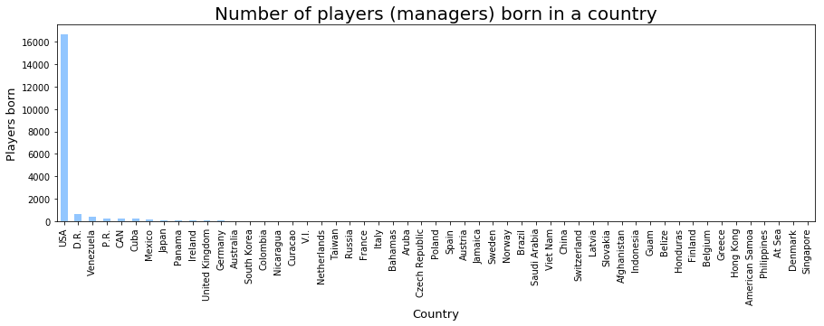

```python
mpl.style.use('seaborn-pastel')
country_counts = MASTER['birthCountry'].value_counts()

plt.figure()
ax = country_counts.plot(kind='bar', figsize=(15, 4))
plt.xlabel('Country', fontsize=13)
plt.ylabel('Players born', fontsize=13)
plt.title('Number of players (managers) born in a country', fontsize=20)
country_counts.head(10)
```

What about `birthState` distribution? Is there some particular "baseball state"?

```python
pc = MASTER['birthState'].value_counts()
player_counts = pd.DataFrame({'abbr':pc.index, 'playersBorn':pc.values})
player_counts.head()
```

|  | abbr | playersBorn |
| --- | --- | --- |
| 0 | CA | 2193 |
| 1 | PA | 1425 |
| 2 | NY | 1216 |
| 3 | IL | 1057 |
| 4 | OH | 1041 |

California, Pennsylvania and New York have the most. But then, these are the most populated states.

Let's try how does it look relative to the state population. Using an information about states' population from a text file `US-States.txt`, compute the value of `playersPer1M` (which is baseball players per capita, born in this state and multiplied by one million):

```python
def parse_state(line):
    name, abbr, pop = line.strip().split(',')
    return (name, abbr, int(pop))

state_pop = pd.DataFrame(
    (parse_state(line) for line in open('data/US-States.txt', 'r')),
    columns=['name', 'abbr', 'population'])
state_data = state_pop.merge(player_counts, on='abbr', how='left')

state_data['playersPer1M'] = \
    1e+6*state_data['playersBorn']/state_data['population']

state_data.sort_values(['playersPer1M'],
                       ascending=False).head()
```

|  | name | abbr | population | playersBorn | playersPer1M |
| --- | --- | --- | --- | --- | --- |
| 47 | Washington D.C. | DC | 572059 | 102 | 178.303287 |
| 37 | Pennsylvania | PA | 12281054 | 1425 | 116.032386 |
| 24 | Missouri | MO | 5595211 | 607 | 108.485632 |
| 20 | Massachusetts | MA | 6349097 | 667 | 105.054309 |
| 34 | Ohio | OH | 11353140 | 1041 | 91.692695 |

Let's use a ["squared choropleth" map](https://github.com/Prooffreader/chorogrid) to display which states give birth to the most baseball players:

```python
cmap = mpl.cm.get_cmap('YlGnBu', 5)
colors = [mpl.colors.rgb2hex(cmap(i)[:3]) for i in range(cmap.N)]
cbin = chorogrid.Colorbin(state_data['playersPer1M'],
                          colors, proportional=True, decimals=None)
cbin.set_decimals(1)
cbin.recalc(fenceposts=True)
cbin.calc_complements(0.5, '#e0e0e0', '#101010')

colors_by_state = cbin.colors_out
font_colors_by_state = cbin.complements
legend_colors = cbin.colors_in
legend_labels = cbin.labels

cg = chorogrid.Chorogrid('data/usa_states.csv', state_data['abbr'], colors_by_state)
cg.set_title('Microplayers per capita, for each state', font_dict={'font-size': 19})
cg.set_legend(legend_colors, legend_labels, title='per capita * 1M')
cg.draw_squares(spacing_dict={'margin_right': 150}, font_colors=font_colors_by_state)
cg.done(show=True)
```

[figure not shown]

So, as we can see, **GO WASHINGTON D.C.!!!**

[figure not shown]

(also, New Mexico has the lowest players per capita... how could you, New Mexico?)

But why that might be?..

#### Does playing in a college league matter?

One assumption is that Washington D.C. may have more colleges per capita, which means more possibilities for talented people to start eventually playing baseball professionally, by jumpstarting their carreer at a college baseball league.

Conveniently, we have tables `CollegePlaying` and `Schools`, so we can accept or reject the null hypothesis H0:

> *H0*: There is **no** monotonic correlation between:
> - number of Major League players born in a state and
> - number of Major League players starting career in a home state's college

> (we take a confidence interval of 95%, i.e. $\alpha=0.05$)

Additionally, we can extract a total number of colleges from an [external data source](http://www.univsearch.com/state.php):

```python
state_colleges = pd.read_csv('data/colleges.csv', sep=';', header=0)
state_data = state_data.merge(state_colleges, on='abbr', how='left')
```

Now do a three-way join between `Master`, `Schools` and `CollegePlaying` tables to find a total number of years that professional players may have spen playing in a college from their birth state:

```python
birth_state_college_years = tables['CollegePlaying']\
    .merge(MASTER, on='playerID')\
    .merge(tables['Schools'], left_on=['schoolID', 'birthState'],
           right_on=['schoolID', 'state'])\
    .groupby(by='playerID', as_index=False)['yearID'].count()\
    .rename(columns={'yearID': 'yearsAtBirthStateCollege'})
MASTER = MASTER.merge(birth_state_college_years, on='playerID', how='left')
```

```python
state_data = MASTER[['yearsAtBirthStateCollege', 'birthState']]\
    .groupby('birthState').count().reset_index()\
    .merge(state_data, how='right', left_on='birthState', right_on='abbr')\
    .sort_values('playersBorn', ascending=False)
state_data['homeCollegePlayersPer1M'] = 1e6*state_data['yearsAtBirthStateCollege']/state_data['population']
state_data['numInstitutionsPer1M'] = 1e6*state_data['numInstitutions']/state_data['population']
```

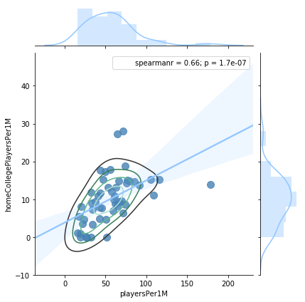

```python
def corr_plot(df, v1, v2):
    ax = sns.jointplot(v1, v2, data=df, kind="reg",
                       scatter_kws=dict(s=100, color="steelblue"), stat_func=stats.spearmanr)
    ax.plot_joint(sns.kdeplot, n_levels=5)

corr_plot(state_data, 'playersPer1M', 'homeCollegePlayersPer1M')
```

Spearman rank-order correlation coefficient is 0.66, which suggests strong correlation between the two variables.

The value of $p$ is way smaller than our $\alpha=0.05$, which means that we *reject the hypothesis H0*, and there is a significant correlation between playing in a college of a home state and becoming a Major League baseball player.

What about total number of institutions vs players born in the state (the initial assumption)?

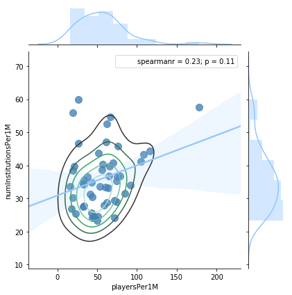

```python
corr_plot(state_data, 'playersPer1M', 'numInstitutionsPer1M')
```

There is some correlation, but it can not be accepted as statistically significant ($p>0.05$), therefor we would not reject *H0* for these two variables.

This could mean that distribution of the colleges that have baseball leagues is not that uniform between different states.

Interestingly, in both cases a prominent outlier is the very Washington D.C.

#### What zodiac signs are represented most?

This one is pointless, but amusing nevertheless, so let's enhance out `Master` table with a Zodiac sign for every player/manager:

```python
zodiac = pd.read_csv('data/zodiac.csv', sep=';', header=0)

def get_sign(master_row):
    month, day = master_row[['birthMonth', 'birthDay']]
    if np.isnan(month) or np.isnan(day):
        return np.NaN
    for _, s, ds, ms, de, me in zodiac.itertuples():
        if (month == ms and day >= ds) or \
           (month == me and day <= de) or \
           (ms < month < me):
            return s
    return np.NaN

MASTER['zodiacSign'] = MASTER.apply(get_sign, axis=1)
pc = MASTER['zodiacSign'].value_counts()
zodiac = zodiac.merge(pd.DataFrame({'sign':pc.index, 'playersOfSign':pc.values}),
                      on='sign', how='left')

zodiac['playersOfSign%'] = zodiac['playersOfSign'].div(
    zodiac['playersOfSign'].sum()).multiply(100)
zodiac.sort_values(['playersOfSign'], ascending=False).head()
```

|  | sign | day_start | month_start | day_end | month_end | playersOfSign | playersOfSign% |
| --- | --- | --- | --- | --- | --- | --- | --- |
| 5 | Virgo | 23 | 8 | 22 | 9 | 1749 | 9.375000 |
| 6 | Libra | 23 | 9 | 22 | 10 | 1695 | 9.085549 |
| 4 | Leo | 23 | 7 | 22 | 8 | 1681 | 9.010506 |
| 7 | Scorpio | 23 | 10 | 21 | 11 | 1651 | 8.849700 |
| 8 | Sagittarius | 22 | 11 | 21 | 12 | 1535 | 8.227916 |

`Virgo` leads here, with `Libra` and `Leo` going second and third respectively.

Let's try and plot it (make a pie chart useful for once):

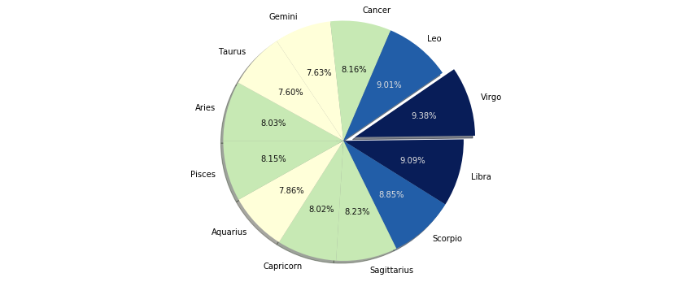

```python
import matplotlib.pyplot as plt

zbin = chorogrid.Colorbin(zodiac['playersOfSign'],
                          colors, proportional=True, decimals=None)
zbin.set_decimals(1)
zbin.recalc(fenceposts=True)
zbin.calc_complements(0.5, '#e0e0e0', '#101010')

labels = zodiac.sign
sizes = zodiac['playersOfSign%']
explode = [0]*12
explode[zodiac['playersOfSign'].argmax()] = 0.1

fig1, ax1 = plt.subplots(figsize=(15,6))
_, _, autotexts = ax1.pie(sizes, explode=explode, labels=labels,
                          autopct='%.2f%%', shadow=True, counterclock=False,
                          startangle=180, colors=zbin.colors_out)
ax1.axis('equal')
for i, at in enumerate(autotexts):
    at.set_color(zbin.complements[i])
plt.show()
```

What we can see is the distribution is rather not about Virgo in particular, but rather about time of the year the baseball players were born: late summer and early autumn.

And apparently, [there exists an explanation to this phenomena](http://www.slate.com/articles/sports/sports_nut/2008/04/the_boys_of_late_summer.html):

> The magical date of Aug. 1 gives a strong hint as to the explanation for this phenomenon. For more than 55 years, July 31 has been the age-cutoff date used by virtually all nonschool-affiliated baseball leagues in the United States. Youth baseball organizations including Little League, Cal Ripken/Babe Ruth, PONY, Dixie Youth, Hap Dumont, Dizzy Dean, American Legion, and more have long used that date to determine which players are eligible for which levels of play.

#### How does players' weight, height and life expectation look over the years?

Let's see how these are distributed, and how they changed over the years:

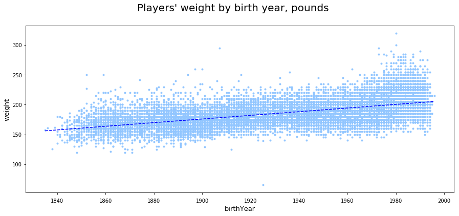

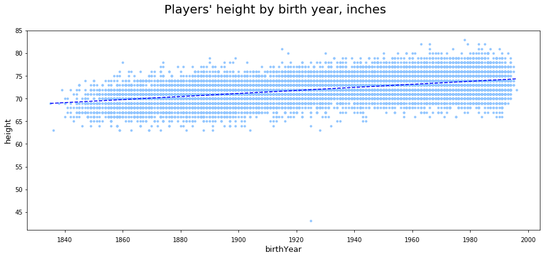

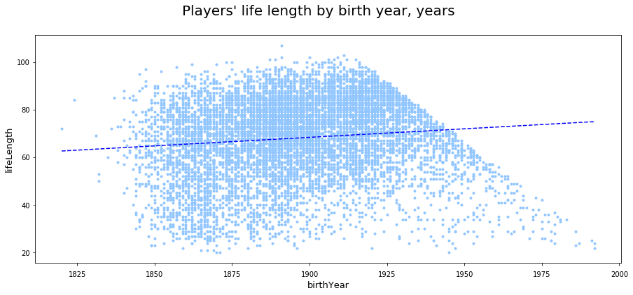

```python
def plot_scatter_trend(df, col_x, col_y, title):
    s = df[[col_x, col_y]].dropna().sort_values([col_x])

    plt.figure(figsize=(15, 6))
    plt.suptitle(title, fontsize=20)
    plt.rcParams['xtick.major.pad'] = 8
    sx = s[col_x]
    sy = s[col_y]
    ax = plt.plot(sx, sy, '.', linestyle='None', markevery=1)

    z = np.polyfit(sx, sy, 1)
    p = np.poly1d(z)
    plt.plot(sx, p(sx), "b--")
    plt.xlabel(col_x, fontsize=13)
    plt.ylabel(col_y, fontsize=13)


plot_scatter_trend(MASTER, 'birthYear', 'weight', "Players' weight by birth year, pounds")
plot_scatter_trend(MASTER, 'birthYear', 'height', "Players' height by birth year, inches")

MASTER['lifeLength'] = MASTER['deathYear'] - MASTER['birthYear']
plot_scatter_trend(MASTER, 'birthYear', 'lifeLength', "Players' life length by birth year, years")
```

The trends show growth over the years in all three attributes, and this agrees with the general US population trends over the last 200 years.

There are some strange outliers, though, in particular in height and weight, so let's look at those points closely:

```python
def show_outliers(df, column, keep_cols, n=3):
    dfs = df.sort_values(column)[keep_cols].dropna()
    show_table_header('{} smallest and {} largest by {}'.format(n, n, column))
    disp.display(pd.concat([dfs[:n], dfs[-n:]]))

keep_cols = ['nameFirst', 'nameLast', 'weight', 'height', 'lifeLength']
show_outliers(MASTER, 'height', keep_cols)
show_outliers(MASTER, 'weight', keep_cols)
show_outliers(MASTER, 'lifeLength', keep_cols)
```

3 smallest and 3 largest by height

|  | nameFirst | nameLast | weight | height | lifeLength |
| --- | --- | --- | --- | --- | --- |
| 5838 | Eddie | Gaedel | 65.0 | 43.0 | 36.0 |
| 12092 | Tom | Morrison | 145.0 | 63.0 | 33.0 |
| 15650 | Frank | Shannon | 155.0 | 63.0 | 61.0 |
| 2447 | Ben | Callahan | 230.0 | 79.0 | 50.0 |
| 12420 | Mike | Naymick | 225.0 | 80.0 | 88.0 |
| 6075 | Johnny | Gee | 225.0 | 81.0 | 73.0 |

3 smallest and 3 largest by weight

|  | nameFirst | nameLast | weight | height | lifeLength |
| --- | --- | --- | --- | --- | --- |
| 5838 | Eddie | Gaedel | 65.0 | 43.0 | 36.0 |
| 3810 | Candy | Cummings | 120.0 | 69.0 | 76.0 |
| 9841 | Dummy | Leitner | 120.0 | 67.0 | 89.0 |
| 2139 | Garland | Buckeye | 260.0 | 72.0 | 78.0 |
| 2033 | Jumbo | Brown | 295.0 | 76.0 | 59.0 |
| 19007 | Walter | Young | 320.0 | 77.0 | 35.0 |

3 smallest and 3 largest by lifeLength

|  | nameFirst | nameLast | weight | height | lifeLength |
| --- | --- | --- | --- | --- | --- |
| 18502 | Gus | Williams | 170.0 | 71.0 | 20.0 |
| 3880 | Jay | Dahl | 183.0 | 70.0 | 20.0 |
| 18288 | John | Weyhing | 185.0 | 74.0 | 21.0 |
| 16848 | Karl | Swanson | 155.0 | 70.0 | 102.0 |
| 10681 | Connie | Marrero | 158.0 | 65.0 | 103.0 |
| 7806 | Red | Hoff | 162.0 | 69.0 | 107.0 |

Looking up the names, we see that the outliers are not mistakes in the data, but rather real numbers of some real baseball players.

> Edward Carl Gaedel (June 8, 1925 – June 18, 1961) was an American with dwarfism who became famous for participating in a Major League Baseball game.[1]

> Gaedel gained recognition in the second game of a St. Louis Browns doubleheader on August 19, 1951. Weighing 65 pounds (29 kg) and standing 3 feet 7 inches (1.09 m) tall, he became the shortest player in the history of the Major Leagues.

Or not less tragic one of Walter Young) ("a Gentle Giant"), the heaviest man in baseball, who died at the age of 35 of heart attack.

Or [Red Hoff](https://en.wikipedia.org/wiki/Red_Hoff), who lived the whole 107 years.

#### How did the players' salary change over the years and what its distribution is?

Let's plot the salaries trend over the years and see how it looks:

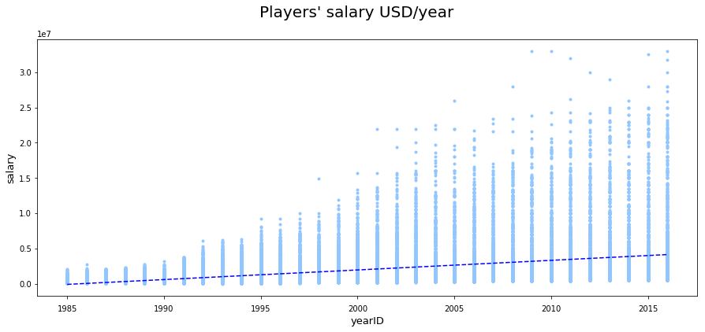

```python
SALARIES = tables['Salaries']
SALARIES = SALARIES[SALARIES['salary'] > 0]
SALARIES = SALARIES.merge(MASTER[['playerID', 'nameFirst', 'nameLast']], how='left', on='playerID')
plot_scatter_trend(SALARIES, 'yearID', 'salary', "Players' salary USD/year")
```

This suggests that salaries are not indexed here, so let's normalize them according to [a CPI estimate](https://www.minneapolisfed.org/community/teaching-aids/cpi-calculator-information/consumer-price-index-1800):

```python
cpi = pd.read_csv('data/cpi.csv', sep=';', header=0)

def get_cpi(year):
    return float(cpi[cpi['year'] == year]['cpi'])

def get_adjusted_dollar_value(price, price_year, adjusted_year):
    cpip = get_cpi(price_year)
    cpia = get_cpi(adjusted_year)
    return 1.0*price*cpia/cpip

YEAR = 2017
def index_row(row):
    return get_adjusted_dollar_value(row['salary'], row['yearID'], YEAR)

SALARIES['salaryIndexed'] = SALARIES.apply(index_row, axis=1)
```

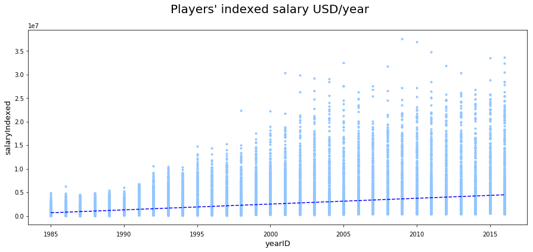

```python
plot_scatter_trend(SALARIES, 'yearID', 'salaryIndexed', "Players' indexed salary USD/year")
```

Even taking consumer index into account, the salaries increased significantly during the last two decades.

The distribution:

```
count      26426.000
mean     2626611.317
std      3961302.646
min        18435.337
25%       407079.130
50%       846994.935
75%      3208830.572
max     37581200.558
Name: salaryIndexed, dtype: float64
```

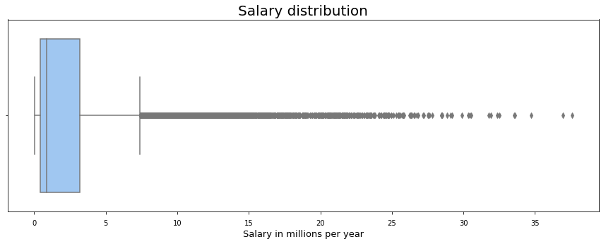

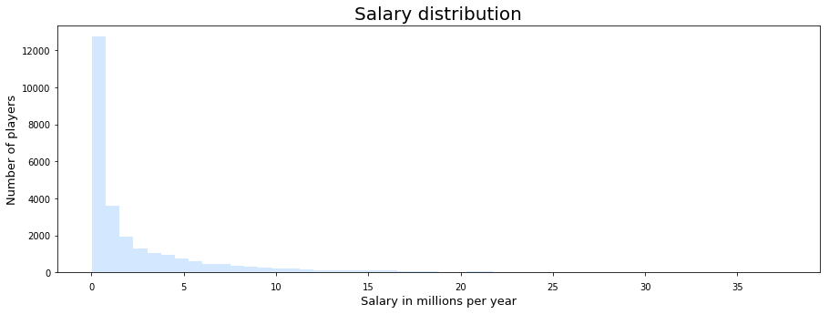

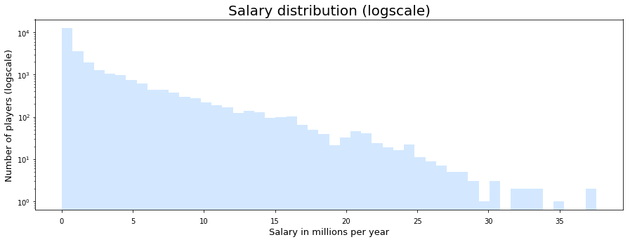

```python
fig, ax = plt.subplots(figsize=(15, 5))
plt.title('Salary distribution', fontsize=20)
sns.boxplot(SALARIES['salaryIndexed']*1e-6, ax=ax, orient='h')
plt.xlabel('Salary in millions per year', fontsize=13)

def plot_salaries_dist(yscale=None):
    fig, ax = plt.subplots(figsize=(15, 5))
    sns.distplot(SALARIES['salaryIndexed']*1e-6, ax=ax, norm_hist=False, kde=False)
    suffix = ' (logscale)' if yscale == 'log' else ''
    plt.title('Salary distribution' + suffix, fontsize=20)
    plt.xlabel('Salary in millions per year', fontsize=13)
    plt.ylabel('Number of players' + suffix, size=13)
    ax.set_yscale(yscale)

plot_salaries_dist('linear')
plot_salaries_dist('log')


pd.set_option('display.float_format', lambda x: '%.3f' % x)
SALARIES['salaryIndexed'].describe()
```

Mean is 2.6 millions per year, and max is 37 millions per year:

```python
show_outliers(SALARIES, 'salaryIndexed', SALARIES.columns)
```

3 smallest and 3 largest by salaryIndexed

|  | yearID | teamID | lgID | playerID | salary | nameFirst | nameLast | salaryIndexed |
| --- | --- | --- | --- | --- | --- | --- | --- | --- |
| 6193 | 1993 | NYA | AL | silveda01 | 10900 | Dave | Silvestri | 18435.337 |
| 9678 | 1997 | FLO | NL | penaal01 | 50000 | Alejandro | Pena | 76098.673 |
| 6658 | 1994 | CHA | AL | carych01 | 50000 | Chuck | Cary | 82420.296 |
| 21943 | 2011 | NYA | AL | rodrial01 | 32000000 | Alex | Rodriguez | 34755029.586 |
| 21107 | 2010 | NYA | AL | rodrial01 | 33000000 | Alex | Rodriguez | 36973294.674 |
| 20284 | 2009 | NYA | AL | rodrial01 | 33000000 | Alex | Rodriguez | 37581200.558 |

[Alex Rodriguez](https://en.wikipedia.org/wiki/Alex_Rodriguez) having such a salary looks about right.

The lowest salaries, though, don't look very credible - this may mean either incorrect data, or for example that players only played (and were paid for) a small part of the year.

Let's put the max indexed yearly salary as an attribute back into the `Master` table:

```python
max_salary = SALARIES[['playerID', 'salaryIndexed']]\
    .groupby(by='playerID').max().reset_index()
MASTER = MASTER.merge(max_salary, on='playerID', how='left')
```

#### How does salary of award winners look comparing to others?

We also add a column `awardsWon` into the `Master` table:

```python
awards = tables['AwardsPlayers'][['playerID', 'awardID']].groupby(by='playerID')\
    .size().to_frame().reset_index().rename(columns={0: 'awardsWon'})
```

```python
MASTER = MASTER.merge(awards, on='playerID', how='left')
MASTER['awardsWon'].fillna(0, inplace=True)
```

```python
STATS = [
    # central tendency:
    ['Mean', np.mean], ['Median', np.median], ['Trimmed mean (10%)', lambda x: stats.trim_mean(x, .1)],
    # variability:
    ['Standard deviation', np.std],
    ['First quartile', np.percentile, 25], ['Third quartile', np.percentile, 75],
    ['Interquartile range', lambda x: np.percentile(x, 75) - np.percentile(x, 25)],
    ['5% percentile', np.percentile, 5], ['95% percentile', np.percentile, 95],
    # other:
    ['Min', np.amin], ['Max', np.amax], ['Count', len]]

def gather_stats(col):
    return [desc[1](col.dropna(), *desc[2:]) for desc in STATS]

def display_stats(series_dict):
    df = pd.DataFrame(list(map(gather_stats, series_dict.values())),
             index = series_dict.keys(), columns = [x[0] for x in STATS])
    disp.display(df.T)
```

```python
award_winners = MASTER['awardsWon'] > 0

display_stats({
    'Max salary of those who won at least one award:':
    MASTER[award_winners]['salaryIndexed'],
    'Max salary of all players':
    MASTER['salaryIndexed']
})
```

|  | Max salary of those who won at least one award: | Max salary of all players |
| --- | --- | --- |
| Mean | 9042018.204 | 2914604.732 |
| Median | 7304811.867 | 824596.378 |
| Trimmed mean (10%) | 8212768.662 | 1870132.240 |
| Standard deviation | 6917129.521 | 4438129.335 |
| First quartile | 3772270.677 | 445399.536 |
| Third quartile | 12892468.452 | 3668800.040 |
| Interquartile range | 9120197.775 | 3223400.504 |
| 5% percentile | 1003005.464 | 189774.247 |
| 95% percentile | 22551448.003 | 12588645.273 |
| Min | 200601.093 | 129115.082 |
| Max | 37581200.558 | 37581200.558 |
| Count | 679.000 | 5147.000 |

Unsurprisingly, award winners have much higher salary that general population of baseball players.

#### Is there difference in salary/awards of left vs right-handed players?

We also can compare how much earn left-handed players vs the right-handed ones:

```python
use_left_hand = (MASTER['bats'] != 'R') | (MASTER['throws'] != 'R')

lh_players = MASTER[use_left_hand]
rh_players = MASTER[~use_left_hand]

display_stats({
    'Left-handed players salary:':
    lh_players['salaryIndexed'],
    'Right-handed players salary:':
    rh_players['salaryIndexed']
})
```

|  | Left-handed players salary: | Right-handed players salary: |
| --- | --- | --- |
| Mean | 2988528.933 | 2866381.946 |
| Median | 928777.019 | 778909.400 |
| Trimmed mean (10%) | 1909025.181 | 1844951.691 |
| Standard deviation | 4567794.298 | 4350786.658 |
| First quartile | 447754.775 | 442562.597 |
| Third quartile | 3641914.353 | 3698528.381 |
| Interquartile range | 3194159.579 | 3255965.784 |
| 5% percentile | 189774.247 | 189774.247 |
| 95% percentile | 12770449.326 | 12383347.874 |
| Min | 129115.082 | 129115.082 |
| Max | 33594841.930 | 37581200.558 |
| Count | 2032.000 | 3115.000 |

Looks like left-handed players have higher (928K) median salary, as compared to right-handed (778K).

What about awards?

```python
def get_awards_percentage(df):
    return 100.0*len(df[df['awardsWon'] > 0])/len(df)

print("Left-handed players with awards: {:.2f}%".format(get_awards_percentage(lh_players)))
print("Right-handed players with awards: {:.2f}%".format(get_awards_percentage(rh_players)))
```

```
Left-handed players with awards: 6.67%
Right-handed players with awards: 7.29%
```

Right-handed players have get awards somewhat more often than left-handed ones (contrast it with salary).

### Conclusion

We only took a peek into the historical baseball data, but there is much more to see there.

This particular dataset has many dimensions and spans a long period of time, so one can ask many interesting questions to the data.

And the data may reveal some exciting stories about the history of baseball, the nature of sport, personal dramas and many more.

One has to remember, however, that the data should also be questioned - many entries are incomplete or downright wrong, so all these stories should be a subject to a careful eye.

And of course, never forget about the fundamental things, such as *correlation is not causation*, and one example of this was a seemengly prevalent zodiac sign of Virgo among the baseball players (which nevertheless had more realistic, albeit less romantic, explanation).

An interesting observation is that it's only during the later years we've got such a powerful and accessible tools for computation and data visualization, like Python with variety of all kinds of libraries, not even mentioning wide availability of computational power, data sources and knowledge thanks to the Internet.

Maybe, if these tools were available earlier, there would be less drama and confusion around the techniques regarding the players evaluation (which gave birth to the techniques like sabermetrics and "Moneyball"), since it would be much easier to look into the data.

But then, sport in general, and baseball is particular is all about the drama. That's what makes it exciting!

### Limitations

Most of the computations were made on incomplete data, which in many cases severely limited the sample sizes (for example, salary data is only available starting from year 1985, and even then it's far from being complete).

Another rather serious problem with above computations is that it uses `Master` table as the source of players data, ignoring the fact that some of the entries in the table belong to non-player managers, thus skewing some of the results.